# Actividad5_DomingoAlvaroMartinez

```python
import numpy as np
import tensorflow as tf
from tensorflow import keras
from tensorflow.keras import layers
import matplotlib.pyplot as plt
from IPython.core.display import display, HTML
# Import numpy after tensorflow and jax to avoid conflicts

import pandas as pd  # Pandas
import matplotlib.pyplot as plt  # Y matplotlib por si queremos hacer graficas.
```

Ejercicio A. Problema de ajuste y cálculo de los pesos a estimar de una RNC

Ejercicio A. Problema de ajuste y cálculo de los pesos a estimar de una RNC

Vamos a realizar el ajuste y el calculo de los pesos a estimar de una RNC. Con los datos que nos han facilitado crearemos una funcion que nos sirva para ser reutilizada en otras ocasiones en las que nos digan otros parametros para el calculo de los pesos de una RNC.

```python
# Vamos primero por definir la funcion para el calculo de los parametros de cada capa. La misma tendra 3 parametros(que no los mismos que genere cada capa), que seran: filtros , tamaño del filtro y lo ultimo el canal de entrada.
# La funcion devolvera el calculo de multiplicar el tamaño del filtro x 2 x los canales de enetrada x los filtros de cada capa + los filtros mismos.
def calcular_parametros(filtros, tamFiltro, canalesEntrada):
    return (tamFiltro ** 2) * canalesEntrada * filtros + filtros


imagenes_entrada = (128, 128, 3)  # Definimos las imagenes de entrada las cuales son de 128 x 128 y de tipo RGB(3 canales)
capas = [
    {'filtros': 100, 'tamFiltro': 3, 'stride': 2}, # Con el stride determinariamos el movimiento del filtro en los pixeles.
    {'filtros': 200, 'tamFiltro': 3, 'stride': 2},
    {'filtros': 300, 'tamFiltro': 5, 'stride': 1},
    {'filtros': 400, 'tamFiltro': 5, 'stride': 1},
    {'filtros': 500, 'tamFiltro': 5, 'stride': 1}
]

# Cálculo de parámetros para cada capa
parametros_totales = 0 # Variable acumulativa para el calculo de parametros.
canalesEntrada = imagenes_entrada[2] # canales de entrada su valor en este caso sera 3
resultados = [] # Creamos un array vacio para llenarlo con los resultados.

nombres_capas = []
parametros_por_capa = []

for i, capa in enumerate(capas): #Bucle para recorrer cada capa
    filtros = capa['filtros']  # Guardamos en filtros el valor de cada vuelta del bucle en el array de capas en la clave filtros.
    tamFiltro = capa['tamFiltro'] #Mismo proceso para tamFiltro
    parametros_capa = calcular_parametros(filtros, tamFiltro, canalesEntrada) # Guardamos en parametros capa el retorno de la funcion de calculo de parametros para cada capa.
    parametros_totales += parametros_capa #Acumulamos en la variable total de parametros en cada vuelta del bucle.
    resultados.append([i + 1, filtros, tamFiltro, canalesEntrada, parametros_capa]) # Guardamos en el array de resultados cada cada valor de cada capa para mostrarlo posteriormente.
    canalesEntrada = filtros  # Haremos esto para que la salida de una capa sea la entrada de la siguiente.
    nombres_capas.append(f"Capa {i}")
    parametros_por_capa.append(parametros_capa)
# Mostrar resultados en un DataFrame
columnas = ['Capa', 'Filtros', 'Tamaño Filtro', 'Canales Entrada', 'Parámetros'] #Creamos un array para el head de cada columna de todas las capas.
df_resultados = pd.DataFrame(resultados, columns=columnas) # Añadimos ambas cosas con pandas a un dataframe.
display(HTML("<h1>Esta es la salida de los parametros de cada capa sin utilizar tensorflow</h1>"))
print(df_resultados)
print(f'Número total de parámetros a estimar: {parametros_totales}') #Imprimimos dataframe y parametros totales a estimar.

display(HTML("<h1>Esta es la salida de los parametros usando tensorflow</h1>"))
# Ahora vamos a usar tensorFlow para ver los resultados de otra manera. Añadiremos ademas la capa flatten( Aplacamos la capa densa ) y dense de capa de salida.
model = tf.keras.Sequential() #Utilizamos el modelo sequential().
model.add(tf.keras.layers.Input(shape=(128, 128, 3)))  # La entrada de la imagen solo se realiza una vez asique como queremos tener el siguiente bucle por si tuvieramos mas capas, la añadimos fuera del bucle.
acti="relu"

for i,capa in enumerate(capas): #Bucle para recorrer el array de las capas. Cambiaremos la activation a partir de la capa 4 para ver si se generan resultados  distintos.

    model.add(tf.keras.layers.Conv2D(filters=capa['filtros'], kernel_size=capa['tamFiltro'], strides=capa['stride'], activation=acti, padding='same'))
    if i==3: #Ultimas dos capas cambiamos a otra activacion para observar posibles cambios
      acti = "sigmoid"

model.add(tf.keras.layers.Flatten())  # Aplanar capa densa
model.add(tf.keras.layers.Dense(10, activation='softmax'))  # Capa de salida

# Resumen del modelo
model.summary()
```

Esta es la salida de los parametros de cada capa sin utilizar tensorflow

```
   Capa  Filtros  Tamaño Filtro  Canales Entrada  Parámetros
0     1      100              3                3        2800
1     2      200              3              100      180200
2     3      300              5              200     1500300
3     4      400              5              300     3000400
4     5      500              5              400     5000500
Número total de parámetros a estimar: 9684200
```

Esta es la salida de los parametros usando tensorflow

```
Model: "sequential_10"
```

```
┏━━━━━━━━━━━━━━━━━━━━━━━━━━━━━━━━━━━━━━┳━━━━━━━━━━━━━━━━━━━━━━━━━━━━━┳━━━━━━━━━━━━━━━━━┓
┃ Layer (type)                         ┃ Output Shape                ┃         Param # ┃
┡━━━━━━━━━━━━━━━━━━━━━━━━━━━━━━━━━━━━━━╇━━━━━━━━━━━━━━━━━━━━━━━━━━━━━╇━━━━━━━━━━━━━━━━━┩
│ conv2d_35 (Conv2D)                   │ (None, 64, 64, 100)         │           2,800 │
├──────────────────────────────────────┼─────────────────────────────┼─────────────────┤
│ conv2d_36 (Conv2D)                   │ (None, 32, 32, 200)         │         180,200 │
├──────────────────────────────────────┼─────────────────────────────┼─────────────────┤
│ conv2d_37 (Conv2D)                   │ (None, 32, 32, 300)         │       1,500,300 │
├──────────────────────────────────────┼─────────────────────────────┼─────────────────┤
│ conv2d_38 (Conv2D)                   │ (None, 32, 32, 400)         │       3,000,400 │
├──────────────────────────────────────┼─────────────────────────────┼─────────────────┤
│ conv2d_39 (Conv2D)                   │ (None, 32, 32, 500)         │       5,000,500 │
├──────────────────────────────────────┼─────────────────────────────┼─────────────────┤
│ flatten_10 (Flatten)                 │ (None, 512000)              │               0 │
├──────────────────────────────────────┼─────────────────────────────┼─────────────────┤
│ dense_22 (Dense)                     │ (None, 10)                  │       5,120,010 │
└──────────────────────────────────────┴─────────────────────────────┴─────────────────┘
```

```
 Total params: 14,804,210 (56.47 MB)
```

```
 Trainable params: 14,804,210 (56.47 MB)
```

```
 Non-trainable params: 0 (0.00 B)
```

Como podemos observar en la primera salida sin tensorflow tendremos un total de 9684200. En cambio con tensorflow se añade una ultima capa que suma 5,120,010 parametros mas .

Para visualizar la diferencia entre cambiar el activation de relu a sigmoid o al valor que nosotros queramos deberiamos de sacar un ejemplo de la capa y ver la diferencia entre el rango de valores, el valor promedio o el tiempo de ejecucion.

# Visualizacion de los parametros en graficas.

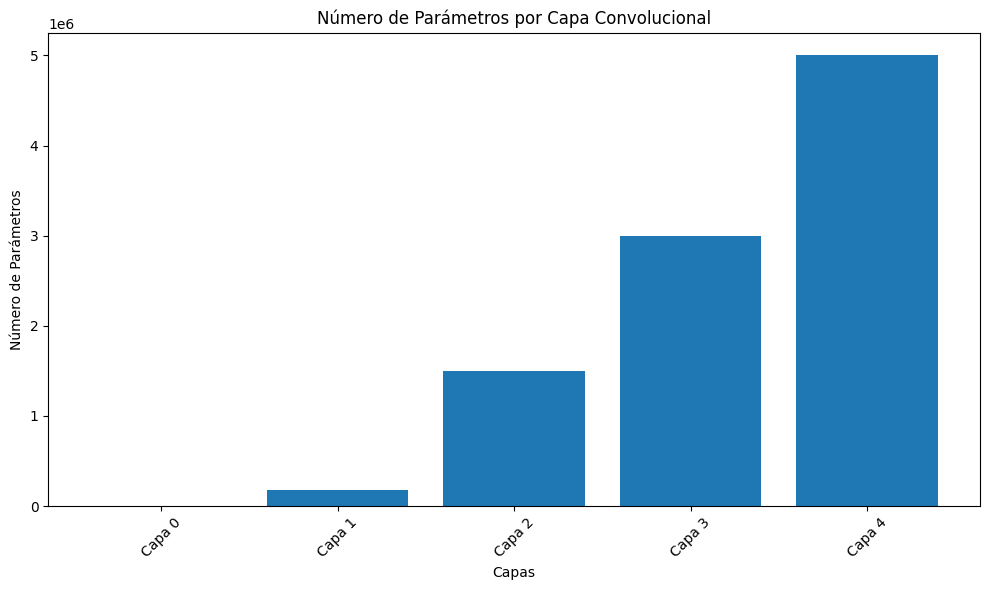

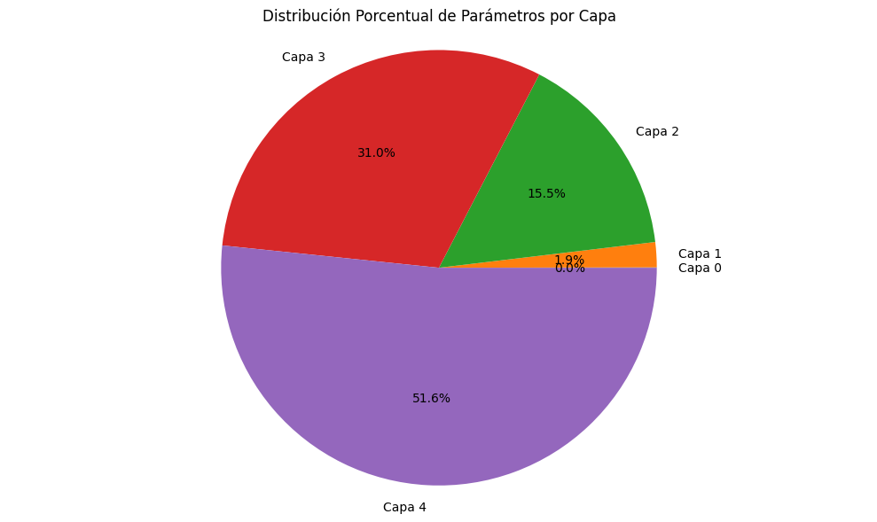

```python
# Visualización de parámetros por capa
plt.figure(figsize=(10, 6))
plt.bar(nombres_capas, parametros_por_capa)
plt.title('Número de Parámetros por Capa Convolucional')
plt.xlabel('Capas')
plt.ylabel('Número de Parámetros')
plt.xticks(rotation=45)
plt.tight_layout()

# Gráfico de distribución porcentual
plt.figure(figsize=(10, 6))
plt.pie(parametros_por_capa, labels=nombres_capas, autopct='%1.1f%%')
plt.title('Distribución Porcentual de Parámetros por Capa')
plt.axis('equal')
plt.tight_layout()

plt.show()
```

Como se ve en las graficas los parametos estan distribuidos de manera ascendente desde las capas inciales hasta las ultimas.

# Procedimiento de una capa de convolución y su utilidad.

Una capa de convolucion es uno de los componentes fundamentales de las redes neuronales y se utilizan para el procesamiento de imagenes. El funcionamiento de la misma se dividiria en estas partes 1.Multiplicar elemento por elemento por los filtros y la entrada 2.Suma de los resultados 3.Se introduce el resultado en la posicion que le toque de la matriz de salida.

Los parametros mas importantes de las capas son: -Tamaño del filtro -Stride -Padding -Canales

Las utilidades principales de una capa de convolucion seria detectar bordes, texturas y formas con el fin de obtener ciertas caracteristicas. Reducion de dimensionalidad. Reconocer objetos en cualquier posicion.

Ejercicio B. Problema de clasificación de imágenes satelitales

```python
from google.colab import drive
drive.mount('/content/drive')
```

```python
import kagglehub

# Download latest version
path = kagglehub.dataset_download("apollo2506/eurosat-dataset")
print("Path to dataset files:", path)
```

```
Path to dataset files: /root/.cache/kagglehub/datasets/apollo2506/eurosat-dataset/versions/6
```

```python
%cd /content/drive/MyDrive/Colab Notebooks
```

```
/content/drive/MyDrive/Colab Notebooks
```

```python
import shutil
destino_drive = '/content/drive/MyDrive/Colab Notebooks' # Aquí va vuestro path dentro de Google Drive.
shutil.move(path, destino_drive)
```

[output not shown]

```python
data_dir= "/content/drive/MyDrive/Colab Notebooks/6/EuroSAT"
```

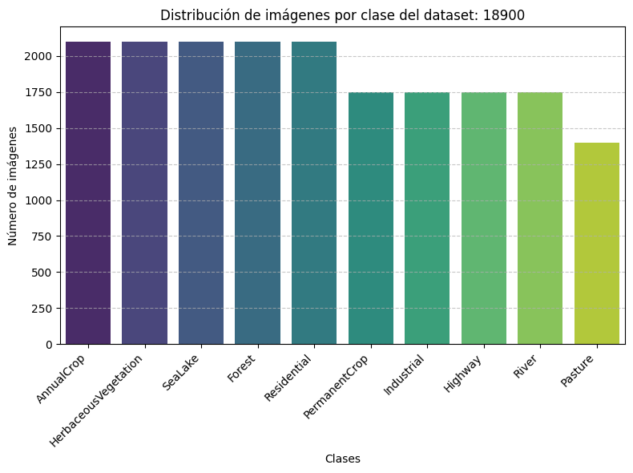

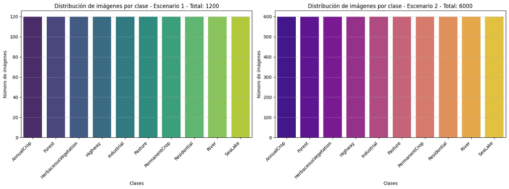

```python
from sklearn.model_selection import train_test_split
import seaborn as sns
from sklearn.utils import resample
# Aprovechamos la carga del dataset del nootebook que vimos de vision por computadora tradicional para empezar con el preparado de los datos
df = pd.read_csv(f"{data_dir}/train.csv", sep=",", header=None, names=["image_path", "label", "category"], dtype=str)
df = df.iloc[1:].reset_index(drop=True)
df.dropna(inplace=True)

#Primera grafica para ver la distribucion de todas las imagenes del dataset.
class_counts=df["category"].value_counts()
total_images = class_counts.sum()
plt.figure(figsize=(8, 6))  # Create a single figure

sns.barplot(x=class_counts.index, y=class_counts.values, hue=class_counts.index, palette="viridis", legend=False)
plt.title(f"Distribución de imágenes por clase del dataset: {total_images}")
plt.xlabel("Clases")
plt.ylabel("Número de imágenes")
plt.grid(axis="y", linestyle="--", alpha=0.7)
plt.xticks(rotation=45, ha="right")

plt.tight_layout() # Improves plot layout
plt.show()

#Funcion que recibe el dataframe y las imagenes para balancear como parametros.
def get_balanced_sample(df, total_samples):
    samples_per_class = total_samples // len(df["category"].unique())
    grouped = df.groupby("category")
    balanced_df = pd.DataFrame()
    for name, group in grouped:
        balanced_df = pd.concat([balanced_df, resample(group, replace=False, n_samples=samples_per_class, random_state=42)])
    return balanced_df

# Preparamos el dataframe de 1200 imagenes.
df_scenario1 = get_balanced_sample(df, 1200)
# Preparamos el de 6000 imagenes.
df_scenario2 = get_balanced_sample(df, 6000)

# Contamos las imagenes de cada dataframe por clase ya balanceados. Con esto nos aseguramos de recibir los mismos datos para evitar posibles errores en el aprendizaje.
class_counts1 = df_scenario1["category"].value_counts()
class_counts2 = df_scenario2["category"].value_counts()

total_images1 = class_counts1.sum()
total_images2 = class_counts2.sum()

# Configurar el gráfico
fig, axes = plt.subplots(1, 2, figsize=(16, 6))

sns.barplot(x=class_counts1.index, y=class_counts1.values, hue=class_counts1.index, palette="viridis", legend=False, ax=axes[0])
axes[0].set_title(f"Distribución de imágenes por clase - Escenario 1 - Total: {total_images1}")
axes[0].set_xlabel("Clases")
axes[0].set_ylabel("Número de imágenes")
axes[0].grid(axis="y", linestyle="--", alpha=0.7)
axes[0].set_xticklabels(axes[0].get_xticklabels(), rotation=45, ha="right")

sns.barplot(x=class_counts2.index, y=class_counts2.values, hue=class_counts2.index, palette="plasma", legend=False, ax=axes[1])
axes[1].set_title(f"Distribución de imágenes por clase - Escenario 2 - Total: {total_images2}")
axes[1].set_xlabel("Clases")
axes[1].set_ylabel("Número de imágenes")
axes[1].grid(axis="y", linestyle="--", alpha=0.7)
axes[1].set_xticklabels(axes[1].get_xticklabels(), rotation=45, ha="right")
plt.tight_layout()
plt.show()
```

```python
import os
import shutil
import cv2

# Creamos las 3 carpetas donde meteremos las imagenes entrenadas. Este era el principal fallo de antes, ya que pense que se podria hacer sin cargarlas en los directorios , el camino ahora al conseguir este paso era mas facil .
base_dir = "/content/EuroSAT_Sampled"
os.makedirs(base_dir, exist_ok=True)
train_dir = os.path.join(base_dir, "train")
test_dir = os.path.join(base_dir, "test")
os.makedirs(train_dir, exist_ok=True)
os.makedirs(test_dir, exist_ok=True)

# Volvemos a reutilziar el codigo del notebook de vision por computadora tradicional y recibiendo la carpeta y el numero de imagenes a cargar las distribuimos en ambas carpetas de test y train.
def load_images_from_folder(folder, num_images):
    images = []
    labels = []
    class_names = sorted(os.listdir(folder))
    for label, class_folder in enumerate(class_names):
        class_path = os.path.join(folder, class_folder)
        if os.path.isdir(class_path):
            image_files = os.listdir(class_path)[:num_images]
            for image_file in image_files:
                image_path = os.path.join(class_path, image_file)
                img = cv2.imread(image_path)
                if img is not None:
                    img = cv2.resize(img, (64, 64)) / 255.0  # Aplicamos la normalizacion ya directamente en este paso. Dividiendo por el numero total de pixeles
                    images.append(img)
                    labels.append(label)
    return np.array(images), np.array(labels)

    # Cargar en las variables que utilizaremos para el entrenamiento de los modelos.
X_train, y_train = load_images_from_folder(data_dir, 100)  # 100 imágenes por clase
X_test, y_test = load_images_from_folder(data_dir, 20)     # 20 imágenes por clase
```

```python
# Creamos la funcion para realizar el entrenamiento y valoracion de los modelos.

from tensorflow.keras.optimizers import Adam
from tensorflow.keras.callbacks import EarlyStopping
from tensorflow.keras.utils import to_categorical

# Utilizamos one hot encoding para las etiquetas. Uno de los problemas que teniamos antes es que al querer que me sacara los dos escenarios de cada modelo juntos generaba mucha lentitud . De esta manera separo cada entrenamiento por un lado y luego ya evaluo el otro escenario con los 3 modelos.
y_train = to_categorical(y_train, num_classes=10)
y_test = to_categorical(y_test, num_classes=10)

def train_and_evaluate(model, X_train, y_train, X_test, y_test, epochs=10): #Creamos una funcion para entrenar y evaluar los modelos de manera que se pueda reutilizar para no tener que escribir el modelo como me paso en la entrega que no tenia el orden.
    model.compile(optimizer=Adam(learning_rate=0.001), loss='categorical_crossentropy', metrics=['accuracy']) #La funcion siempre recibira el modelo a evaluar y las imagenes procesadas. Compilamos el modelo con un learning rate bajo. He hecho algunas
                                                                                                              #p ruebas y el modelo con una tasa mas alta aprende mas rapido. Cuando la tasa es mas baja aprende mas lento pero obtienes mejores resultados.
    early_stop = EarlyStopping(monitor='val_loss', patience=3)

    history = model.fit(X_train, y_train, validation_data=(X_test, y_test), epochs=epochs, callbacks=[early_stop], batch_size=32) #Entrenamos el modelo con las imagenes procesadas.

    loss, accuracy = model.evaluate(X_test, y_test) #Utilizamos model evaluate para la valoracion de los modelos.
    print(f'Precisión del modelo: {accuracy:.2f}')

    # Realizar predicciones
    y_pred = model.predict(X_test)
    y_pred_labels = np.argmax(y_pred, axis=1)
    y_test_labels = np.argmax(y_test, axis=1)

    # Evaluar el rendimiento
    print('Accuracy:', accuracy_score(y_test_labels, y_pred_labels))
    print('Classification Report:')
    print(classification_report(y_test_labels, y_pred_labels, zero_division=1))

    return history
```

```python
## Creamos un array de modelos. Simple . Como ya comente antes, esto me ha ayudado a simplificar mas el codigo y poder obtener resultados.

from tensorflow.keras.models import Sequential
from tensorflow.keras.layers import Conv2D, MaxPooling2D, Flatten, Dense, Dropout
from sklearn.metrics import classification_report, accuracy_score


modelos = {} #El primer modelo es una copia literal del modelo del notebook de vision por computadora tradicional.

modelos["modelo1"] = Sequential([
    Conv2D(32, (3, 3), activation='relu', input_shape=(64, 64, 3)),
    MaxPooling2D((2, 2)),
    Conv2D(64, (3, 3), activation='relu'),
    MaxPooling2D((2, 2)),
    Conv2D(128, (3, 3), activation='relu'),
    MaxPooling2D((2, 2)),
    Flatten(),
    Dense(128, activation='relu'),
    Dense(10, activation='softmax')
])

modelos["modelo2"] = Sequential([ #Para el segundo modelo simplemente le metemos un kernel de 5x5 para ver posibles cambios en los resultados.
    Conv2D(32, (5, 5), activation='relu', padding="SAME", input_shape=(64, 64, 3)),
    MaxPooling2D(pool_size=(2, 2)),
    Conv2D(64, (5, 5), activation='relu', padding="SAME"),
    MaxPooling2D(pool_size=(2, 2)),
    Conv2D(128, (5, 5), activation='relu', padding="SAME"),
    MaxPooling2D(pool_size=(2, 2)),
    Flatten(),
    Dense(128, activation='relu'),
    Dense(10, activation='softmax')
])

modelos["modelo3"] = Sequential([ #En el utlimo tendremos varias capas mas incluyendo dropout . Ademas a una capa dense de damo 256 de valor.
    Conv2D(64, (3, 3), activation='relu', input_shape=(64, 64, 3)),
    MaxPooling2D(pool_size=(2, 2)),
    Conv2D(128, (3, 3), activation='relu'),
    MaxPooling2D(pool_size=(2, 2)),
    Conv2D(256, (3, 3), activation='relu'),
    MaxPooling2D(pool_size=(2, 2)),
    Conv2D(512, (3, 3), activation='relu'),
    MaxPooling2D(pool_size=(2, 2)),
    Flatten(),
    Dense(256, activation='relu'),
    Dropout(0.5),
    Dense(128, activation='relu'),
    Dropout(0.5),
    Dense(10, activation='softmax')
])

#Bucle para entrenar los modelos.
for i, model in enumerate(modelos.values()):
    print(f"Entrenando Modelo CNN {i+1}")
    train_and_evaluate(model, X_train, y_train, X_test, y_test)
```

```
Entrenando Modelo CNN 1
32/32 ━━━━━━━━━━━━━━━━━━━━ 10s 253ms/step - accuracy: 0.1162 - loss: 2.2155 - val_accuracy: 0.1800 - val_loss: 1.8104
32/32 ━━━━━━━━━━━━━━━━━━━━ 8s 193ms/step - accuracy: 0.2742 - loss: 1.7870 - val_accuracy: 0.4650 - val_loss: 1.3666
32/32 ━━━━━━━━━━━━━━━━━━━━ 8s 241ms/step - accuracy: 0.4169 - loss: 1.5144 - val_accuracy: 0.5150 - val_loss: 1.2781
32/32 ━━━━━━━━━━━━━━━━━━━━ 6s 192ms/step - accuracy: 0.3907 - loss: 1.5377 - val_accuracy: 0.5000 - val_loss: 1.2459
32/32 ━━━━━━━━━━━━━━━━━━━━ 10s 183ms/step - accuracy: 0.4948 - loss: 1.3250 - val_accuracy: 0.5950 - val_loss: 1.1362
32/32 ━━━━━━━━━━━━━━━━━━━━ 12s 229ms/step - accuracy: 0.5023 - loss: 1.2799 - val_accuracy: 0.5000 - val_loss: 1.2809
32/32 ━━━━━━━━━━━━━━━━━━━━ 6s 182ms/step - accuracy: 0.5477 - loss: 1.2270 - val_accuracy: 0.6700 - val_loss: 1.0165
32/32 ━━━━━━━━━━━━━━━━━━━━ 10s 183ms/step - accuracy: 0.5934 - loss: 1.0676 - val_accuracy: 0.6450 - val_loss: 1.0050
32/32 ━━━━━━━━━━━━━━━━━━━━ 11s 194ms/step - accuracy: 0.5747 - loss: 1.1681 - val_accuracy: 0.7550 - val_loss: 0.7940
32/32 ━━━━━━━━━━━━━━━━━━━━ 12s 252ms/step - accuracy: 0.6061 - loss: 0.9849 - val_accuracy: 0.7000 - val_loss: 0.8662
7/7 ━━━━━━━━━━━━━━━━━━━━ 0s 47ms/step - accuracy: 0.7440 - loss: 0.7955
```

[output not shown]

```
Precisión del modelo: 0.70
7/7 ━━━━━━━━━━━━━━━━━━━━ 0s 55ms/step
Accuracy: 0.7
Classification Report:
              precision    recall  f1-score   support

           0       0.48      1.00      0.65        20
           1       0.67      0.90      0.77        20
           2       0.64      0.35      0.45        20
           3       1.00      0.50      0.67        20
           4       1.00      0.85      0.92        20
           5       0.75      0.75      0.75        20
           6       0.60      0.45      0.51        20
           7       0.70      0.95      0.81        20
           8       0.79      0.75      0.77        20
           9       0.83      0.50      0.62        20

    accuracy                           0.70       200
   macro avg       0.75      0.70      0.69       200
weighted avg       0.75      0.70      0.69       200

Entrenando Modelo CNN 2
32/32 ━━━━━━━━━━━━━━━━━━━━ 21s 590ms/step - accuracy: 0.1486 - loss: 2.2305 - val_accuracy: 0.2850 - val_loss: 1.8641
32/32 ━━━━━━━━━━━━━━━━━━━━ 20s 617ms/step - accuracy: 0.2366 - loss: 1.9489 - val_accuracy: 0.2850 - val_loss: 1.8078
32/32 ━━━━━━━━━━━━━━━━━━━━ 19s 596ms/step - accuracy: 0.3277 - loss: 1.7768 - val_accuracy: 0.4050 - val_loss: 1.5215
32/32 ━━━━━━━━━━━━━━━━━━━━ 22s 660ms/step - accuracy: 0.3885 - loss: 1.5539 - val_accuracy: 0.3250 - val_loss: 1.5684
32/32 ━━━━━━━━━━━━━━━━━━━━ 19s 597ms/step - accuracy: 0.3674 - loss: 1.6104 - val_accuracy: 0.4650 - val_loss: 1.3136
32/32 ━━━━━━━━━━━━━━━━━━━━ 20s 594ms/step - accuracy: 0.4498 - loss: 1.3663 - val_accuracy: 0.4700 - val_loss: 1.1444
32/32 ━━━━━━━━━━━━━━━━━━━━ 21s 589ms/step - accuracy: 0.4872 - loss: 1.3106 - val_accuracy: 0.5200 - val_loss: 1.2060
32/32 ━━━━━━━━━━━━━━━━━━━━ 20s 594ms/step - accuracy: 0.5704 - loss: 1.1293 - val_accuracy: 0.7500 - val_loss: 0.8809
32/32 ━━━━━━━━━━━━━━━━━━━━ 21s 605ms/step - accuracy: 0.6262 - loss: 1.0314 - val_accuracy: 0.6400 - val_loss: 1.0180
32/32 ━━━━━━━━━━━━━━━━━━━━ 18s 578ms/step - accuracy: 0.6045 - loss: 1.0991 - val_accuracy: 0.6800 - val_loss: 0.8700
7/7 ━━━━━━━━━━━━━━━━━━━━ 1s 128ms/step - accuracy: 0.7031 - loss: 0.8332
Precisión del modelo: 0.68
```

[output not shown]

```
7/7 ━━━━━━━━━━━━━━━━━━━━ 1s 132ms/step
Accuracy: 0.68
Classification Report:
              precision    recall  f1-score   support

           0       0.67      1.00      0.80        20
           1       0.52      0.65      0.58        20
           2       0.50      0.20      0.29        20
           3       0.92      0.55      0.69        20
           4       1.00      0.90      0.95        20
           5       0.67      0.80      0.73        20
           6       0.56      0.75      0.64        20
           7       0.80      1.00      0.89        20
           8       0.92      0.60      0.73        20
           9       0.39      0.35      0.37        20

    accuracy                           0.68       200
   macro avg       0.69      0.68      0.66       200
weighted avg       0.69      0.68      0.66       200

Entrenando Modelo CNN 3
32/32 ━━━━━━━━━━━━━━━━━━━━ 29s 720ms/step - accuracy: 0.1023 - loss: 2.2940 - val_accuracy: 0.1550 - val_loss: 2.2783
32/32 ━━━━━━━━━━━━━━━━━━━━ 39s 671ms/step - accuracy: 0.1763 - loss: 2.1820 - val_accuracy: 0.2250 - val_loss: 1.9118
32/32 ━━━━━━━━━━━━━━━━━━━━ 41s 679ms/step - accuracy: 0.1917 - loss: 1.9993 - val_accuracy: 0.2300 - val_loss: 1.8385
32/32 ━━━━━━━━━━━━━━━━━━━━ 41s 687ms/step - accuracy: 0.2328 - loss: 1.9349 - val_accuracy: 0.2450 - val_loss: 1.7638
32/32 ━━━━━━━━━━━━━━━━━━━━ 42s 714ms/step - accuracy: 0.2453 - loss: 1.8889 - val_accuracy: 0.2900 - val_loss: 1.6180
32/32 ━━━━━━━━━━━━━━━━━━━━ 41s 721ms/step - accuracy: 0.2927 - loss: 1.7874 - val_accuracy: 0.3650 - val_loss: 1.5552
32/32 ━━━━━━━━━━━━━━━━━━━━ 42s 745ms/step - accuracy: 0.2951 - loss: 1.7387 - val_accuracy: 0.4100 - val_loss: 1.4977
32/32 ━━━━━━━━━━━━━━━━━━━━ 40s 708ms/step - accuracy: 0.3222 - loss: 1.6860 - val_accuracy: 0.4550 - val_loss: 1.3346
32/32 ━━━━━━━━━━━━━━━━━━━━ 22s 677ms/step - accuracy: 0.3679 - loss: 1.5298 - val_accuracy: 0.4150 - val_loss: 1.4749
32/32 ━━━━━━━━━━━━━━━━━━━━ 40s 662ms/step - accuracy: 0.3723 - loss: 1.5650 - val_accuracy: 0.4700 - val_loss: 1.3056
7/7 ━━━━━━━━━━━━━━━━━━━━ 1s 128ms/step - accuracy: 0.5900 - loss: 1.2130
Precisión del modelo: 0.47
7/7 ━━━━━━━━━━━━━━━━━━━━ 1s 144ms/step
Accuracy: 0.47
Classification Report:
              precision    recall  f1-score   support

           0       0.31      0.95      0.46        20
           1       0.43      1.00      0.61        20
           2       0.67      0.10      0.17        20
           3       0.60      0.15      0.24        20
           4       0.69      0.90      0.78        20
           5       0.62      0.50      0.56        20
           6       0.23      0.15      0.18        20
           7       0.86      0.30      0.44        20
           8       0.63      0.60      0.62        20
           9       0.33      0.05      0.09        20

    accuracy                           0.47       200
   macro avg       0.54      0.47      0.42       200
weighted avg       0.54      0.47      0.42       200
```

En la valoracion de los tres modelos podemo observar que el que mejores resultados en accuraccy seria el primer modelo. Esto nos deja ver que tendra la estructura mas adecuada de aprendizaje para el tipo de imagenes que ha procesado. El segundo modelo tiene buenos resultados en f-score.

```python
## Cargamos las nuevas imagenes para ver los modelos con el escenario numero dos.
X_train_2, y_train_2 = load_images_from_folder(data_dir, 500)
X_test_2, y_test_2 = load_images_from_folder(data_dir, 100)

# Volvemos a hacer a las etiquetas one hot encoding.
y_train_2 = to_categorical(y_train_2, num_classes=10)
y_test_2 = to_categorical(y_test_2, num_classes=10)

# Bucle para evaluar los modelos con las imagenes del segundo escenario.
for i, model in enumerate(modelos.values()):
    print(f"Entrenando Modelo CNN {i+1} en el Escenario 2")
    train_and_evaluate(model, X_train_2, y_train_2, X_test_2, y_test_2)
```

```
Entrenando Modelo CNN 1 en el Escenario 2
157/157 ━━━━━━━━━━━━━━━━━━━━ 41s 245ms/step - accuracy: 0.5992 - loss: 1.1326 - val_accuracy: 0.6540 - val_loss: 0.9755
157/157 ━━━━━━━━━━━━━━━━━━━━ 36s 214ms/step - accuracy: 0.6775 - loss: 0.9168 - val_accuracy: 0.7290 - val_loss: 0.7479
157/157 ━━━━━━━━━━━━━━━━━━━━ 40s 207ms/step - accuracy: 0.7179 - loss: 0.7711 - val_accuracy: 0.7950 - val_loss: 0.6163
157/157 ━━━━━━━━━━━━━━━━━━━━ 42s 213ms/step - accuracy: 0.7563 - loss: 0.6914 - val_accuracy: 0.8080 - val_loss: 0.5694
157/157 ━━━━━━━━━━━━━━━━━━━━ 41s 212ms/step - accuracy: 0.7796 - loss: 0.6189 - val_accuracy: 0.8180 - val_loss: 0.5163
157/157 ━━━━━━━━━━━━━━━━━━━━ 43s 226ms/step - accuracy: 0.7910 - loss: 0.5651 - val_accuracy: 0.7330 - val_loss: 0.7432
157/157 ━━━━━━━━━━━━━━━━━━━━ 38s 207ms/step - accuracy: 0.7982 - loss: 0.5458 - val_accuracy: 0.8200 - val_loss: 0.5139
157/157 ━━━━━━━━━━━━━━━━━━━━ 35s 220ms/step - accuracy: 0.8262 - loss: 0.4624 - val_accuracy: 0.8850 - val_loss: 0.3433
157/157 ━━━━━━━━━━━━━━━━━━━━ 40s 214ms/step - accuracy: 0.8116 - loss: 0.5157 - val_accuracy: 0.8840 - val_loss: 0.3296
157/157 ━━━━━━━━━━━━━━━━━━━━ 34s 219ms/step - accuracy: 0.8566 - loss: 0.3906 - val_accuracy: 0.9020 - val_loss: 0.2970
32/32 ━━━━━━━━━━━━━━━━━━━━ 3s 87ms/step - accuracy: 0.9114 - loss: 0.2653
Precisión del modelo: 0.90
32/32 ━━━━━━━━━━━━━━━━━━━━ 2s 49ms/step
Accuracy: 0.902
Classification Report:
              precision    recall  f1-score   support

           0       0.80      0.96      0.87       100
           1       0.93      0.93      0.93       100
           2       0.95      0.77      0.85       100
           3       0.91      0.83      0.87       100
           4       0.95      0.99      0.97       100
           5       0.84      0.93      0.88       100
           6       0.80      0.88      0.84       100
           7       0.99      0.98      0.98       100
           8       0.94      0.78      0.85       100
           9       0.96      0.97      0.97       100

    accuracy                           0.90      1000
   macro avg       0.91      0.90      0.90      1000
weighted avg       0.91      0.90      0.90      1000

Entrenando Modelo CNN 2 en el Escenario 2
157/157 ━━━━━━━━━━━━━━━━━━━━ 102s 637ms/step - accuracy: 0.5334 - loss: 1.3734 - val_accuracy: 0.6840 - val_loss: 0.8388
157/157 ━━━━━━━━━━━━━━━━━━━━ 138s 612ms/step - accuracy: 0.6669 - loss: 0.9171 - val_accuracy: 0.7630 - val_loss: 0.6960
157/157 ━━━━━━━━━━━━━━━━━━━━ 94s 601ms/step - accuracy: 0.6911 - loss: 0.8488 - val_accuracy: 0.7140 - val_loss: 0.8365
157/157 ━━━━━━━━━━━━━━━━━━━━ 144s 615ms/step - accuracy: 0.7151 - loss: 0.7795 - val_accuracy: 0.6800 - val_loss: 0.8544
157/157 ━━━━━━━━━━━━━━━━━━━━ 96s 613ms/step - accuracy: 0.7645 - loss: 0.6543 - val_accuracy: 0.7030 - val_loss: 0.7583
32/32 ━━━━━━━━━━━━━━━━━━━━ 6s 196ms/step - accuracy: 0.7007 - loss: 0.7117
```

[output cut: 38 more lines]

```

           0       0.78      0.94      0.85       100
           1       0.88      0.94      0.91       100
           2       0.78      0.58      0.67       100
           3       0.87      0.58      0.69       100
           4       0.93      0.97      0.95       100
           5       0.73      0.92      0.81       100
           6       0.57      0.82      0.67       100
           7       0.96      0.98      0.97       100
           8       0.92      0.67      0.77       100
           9       1.00      0.82      0.90       100

    accuracy                           0.82      1000
   macro avg       0.84      0.82      0.82      1000
weighted avg       0.84      0.82      0.82      1000
```

En este caso valoraremos los 3 modelos en este escenario 2 y comparando tambien con los anteriores resultados. En este caso una vez mas el modelo con mejores resultados vuelve a ser el primer modelo que obtiene una precision del nodelo de 0.90. El aumento de las imagenes ha hecho que la mejoria sea notoria. Ademas tambien se ha visto beneficiado de este aumento de las imagenes el tercer modelo que sube a casi el doble su precision. Este ultimo modelo tiene unas metricas muy altas y el acurazzy asciende tambiena 0.822

Ejercicio C. Problema de simulación de redes con TensorFlow Playground

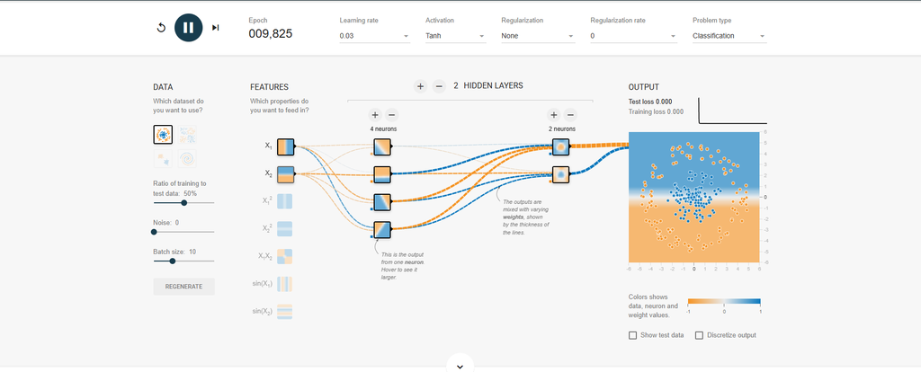

En la imagen vemos como la primera capa aprenderia patrones y la segunda los combina con patrones mas complejos.

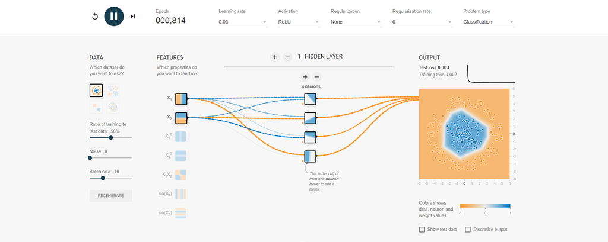

En la segunda imagen veremos como la funcion relu cambia los limites son mas rectos y es por que la funcion genera zonas mas lineales.

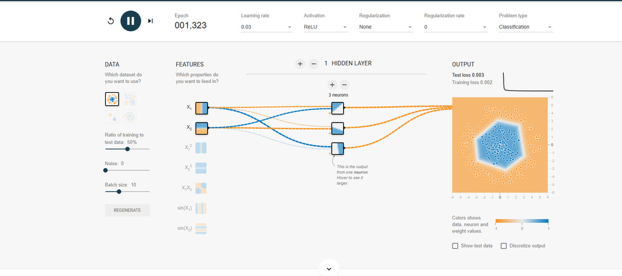

Para este tercer punto hemos realizado hasta 5 pruebas en las que hemos visto diferencias a la hora de entrenar y realizar el aprendizaje. Esto se debe a que cuando le quitas neuronas a la red pierde capacidad para representar patrones mas complejos.

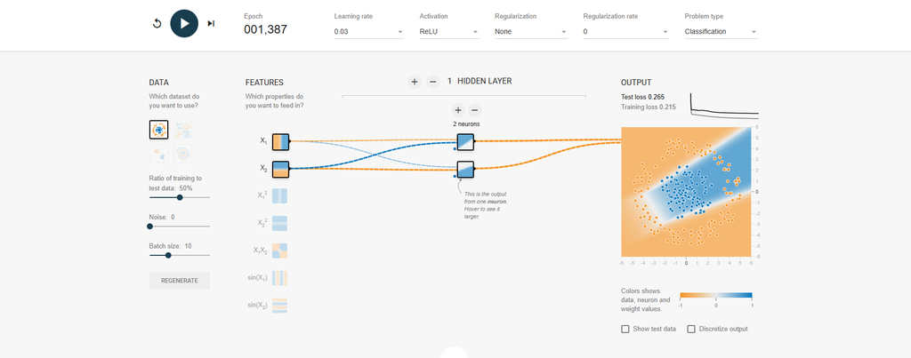

En esta imagen vemos como la red no puede aprender el patron dandose un caso de underfitting

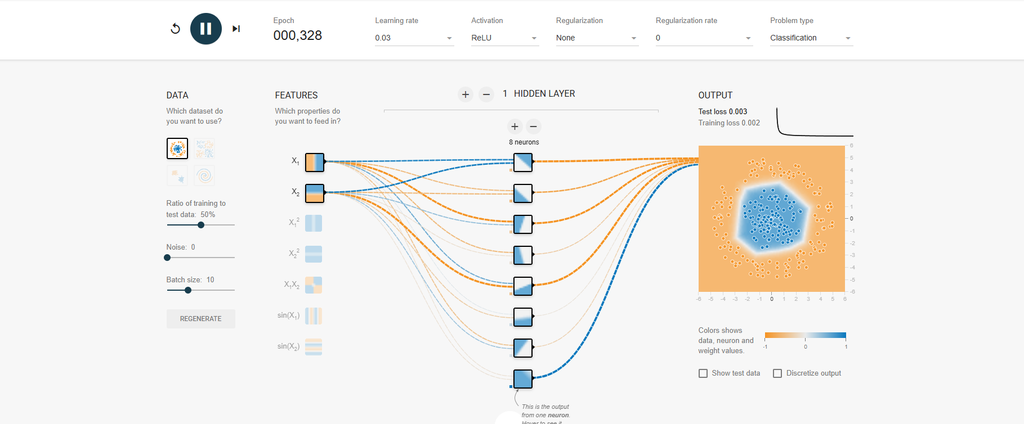

En esta imagen vemos como hemos añadio hasta 8 neuronas. El test loss se reduce rapidamente y el aprendizaje es mucho mas rapido.

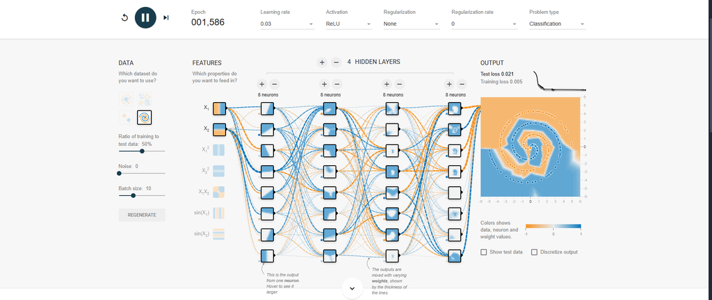

En este caso al poner 4 capas ocultas y 8 neuronas en cada una el proceso tarda mas. Se produce el desvanecimiento del gradiente que se da cuando las capas mas cercanas a la entrada reciben actualizaciones mas pequeñas. Lo podemos llegar a solucionar con optimizadores.

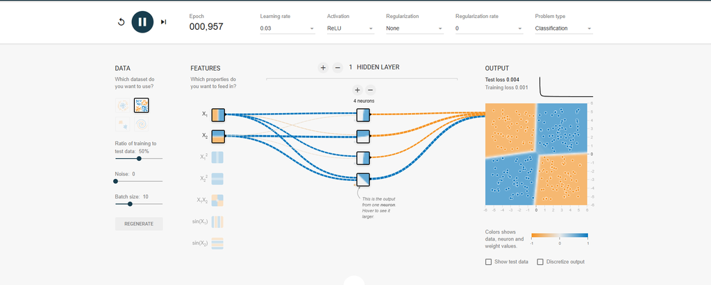

Esta vez hemos hecho una red con un dataset en Xor y 1 capa con 4 neuronas. El entrenamiento ha sido bastante rapido.

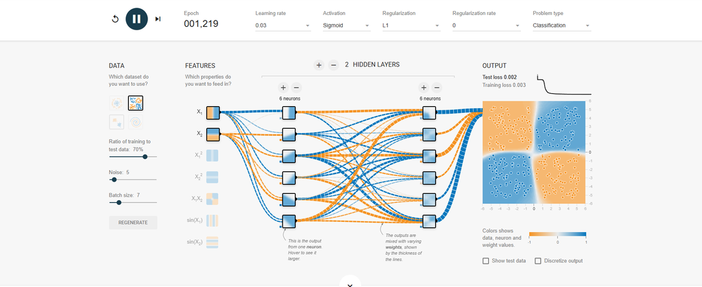

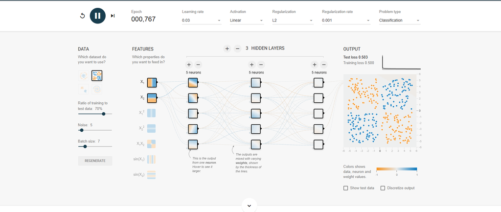

Para esta ultima red hemos puesto una activation linear y regularization en l2 con un rate de 0.001. Hemos podido observar que no consigue aprender el patron y se produce nuevamente un caso de underfitting.